# Ad Exposure Trends and Viewer Insights

## Introduction

This visual data story explores ad exposure based on observational data collected through a structured Google Form. The analysis includes frequency, timing, and sentiment regarding various ad types.

## Number of Ads by Type

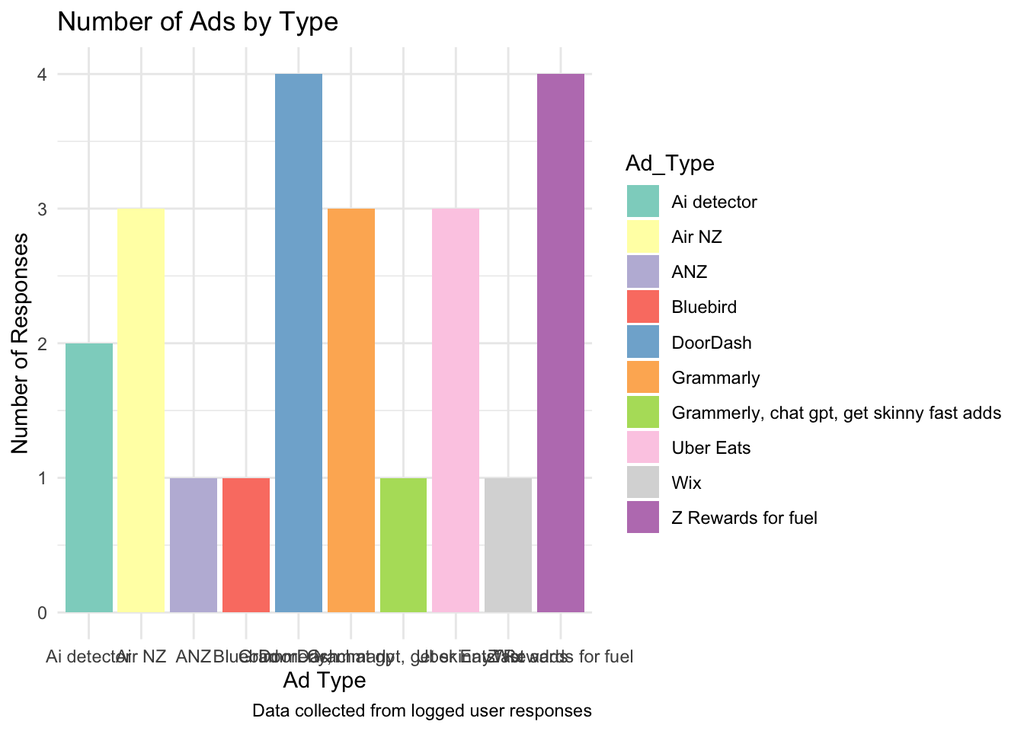

**Alt-text**: Bar chart showing how many responses were recorded for each ad type. The purpose of this bar chart is to display the frequency with which participants recorded each type of advertisement. It’s a simple frequency count with Ad_Type groupings.

## Top 5 Most Viewed Ads

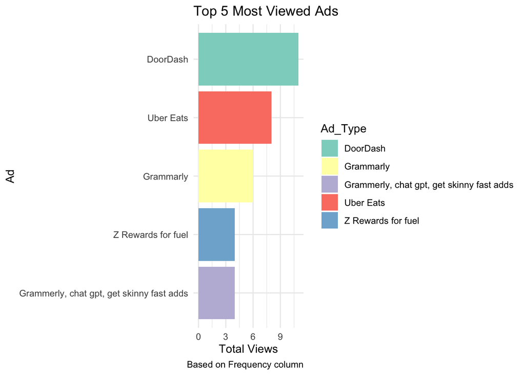

**Alt-text**: Horizontal bar chart showing the top 5 ad types based on total views. This horizontal bar chart uses the Frequency column to rank ad types according to the number of times respondents reported seeing them. Only the top 5 are highlighted.

What it indicates: It draws attention to the dataset’s most noticeable or recurring advertisements. This plot illustrates how an advertisement may be displayed less frequently overall but highly frequently among particular users.

## Average Ad Frequency by Hour

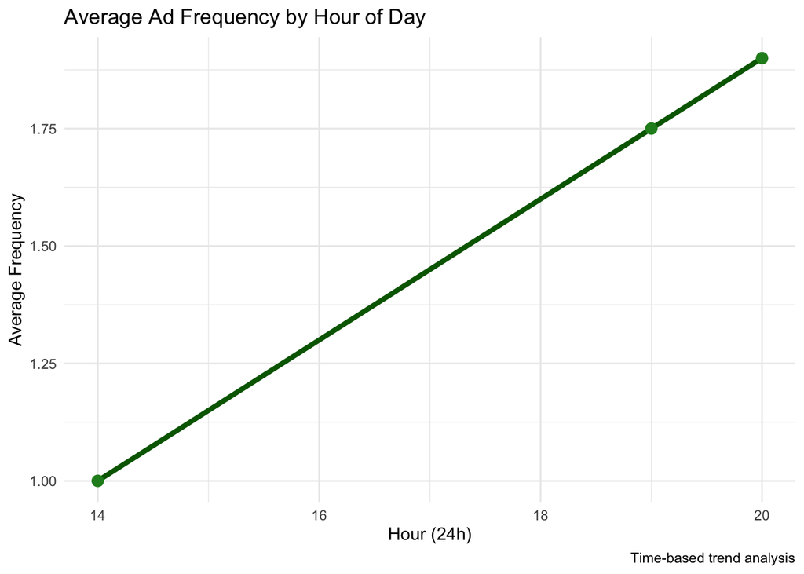

**Alt-text**: Line graph showing how average ad frequency changes by hour throughout the day.Purpose: This line graph shows the average number of times ads were seen by the hour of day, based on the timestamp recorded.

What it tells us: It gives insight into when ad exposure tends to peak. For example, you might observe that users see more ads during midday or evening hours. This can inform timing strategies for ad placements.

## Observations Mentioning YouTube

```
## [1] "It comes up quite often both before watching the YouTube videos and during"
## [2] "Adds are stupid everyone should get YouTube premium for free 😊"
```

**Alt-text**: List of user-submitted observations that mention ‘YouTube’.Purpose: This text output filters for open-ended comments where respondents mentioned “YouTube” in their observations.

What it tells us: It extracts user feedback specifically about YouTube ads, which might reveal attitudes, patterns, or specific examples worth investigating further. It adds a qualitative layer to the analysis.

## Conclusion

This data story has shown key trends in ad exposure, highlighting which types of ads are most common, when they’re most seen, and how people engage with them. The results offer insight into the user experience of ad saturation in different contexts and times of day.

*End of Report*